# xwMOOC 금융(Finance)

블록체인(Blockchain)

## 1. 블록체인 [^1] [^2]

비트코인을 블록체인과 동일시하는 경향이 있지만, 관련이 있지만 블록체인을 구현한 한 사례로 암호화폐 비트코인을 바라보는 관점이 타당해 보인다. 결제시스템 예를 들어 페이팔과 같은 시스템에서 필요로 하는 중앙 집중형 데이터베이스를 가지고 있을 필요가 없다는 점이 기존 방식과 큰 차이점으로 새로운 혁신의 원동력으로 받아들여지고 있다.

블록체인(block chain)은 관리 대상 데이터를 ’블록’이라고 하는 소규모 데이터들이 P2P방식을 기반으로 생성된 체인 형태의 연결고리 기반 분산 데이터 저장환경에 저장되어 누구도 임의로 수정될 수 없고 누구나 변경의 결과를 열람할 수 있는 분산컴퓨팅 기술 기반의 데이터 위변조 방지 기술이다. 이는 근본적으로 분산 데이터 저장기술의 한 형태로, 지속적으로 변경되는 데이터를 모든 참여 노드에 기록한 변경 리스트로서 분산 노드의 운영자에 의한 임의 조작이 불가능하도록 고안되었다. 잘 알려진 블록체인의 응용사례는 암호화폐의 거래과정을 기록하는 탈중앙화된 전자장부로서 **비트코인(Bitcoin)**이 있다. 비트코인을 비롯한 대부분의 암호화폐들이 블록체인 기술 형태에 기반하고 있다.

[interactive chart not shown]

## 2. 암호화폐 시가 총액 [^3]

```r
# 0. 환경설정 --------
# library(rockchain) # devtools::install_github("leonawicz/rockchain")
library(tidyverse)
# devtools::install_github("amrrs/coinmarketcapr")
library(coinmarketcapr)
library(DT)
library(lubridate)
library(treemap)
library(d3treeR)
library(extrafont)
loadfonts()
library(coindeskr)
library(dygraphs)

# 1. 데이터 가져오기 --------

market_today <- get_marketcap_ticker_all() %>%
    tbl_df %>%
    mutate(last_updated = as.POSIXct(as.integer(last_updated), origin="1970-01-01"))

# 2. 암호화폐 시장규모 --------
## 2.1. 표

market_today %>%
    datatable() %>%
      formatCurrency(c("rank", "price_usd", "price_btc", "X24h_volume_usd",
                       "market_cap_usd", "available_supply", "total_supply", "max_supply"),
                     currency="", digits=0)
```

|  | id | name | symbol | rank | price_usd | price_btc | X24h_volume_usd | market_cap_usd | available_supply | total_supply | max_supply | percent_change_1h | percent_change_24h | percent_change_7d | last_updated |
| --- | --- | --- | --- | --- | --- | --- | --- | --- | --- | --- | --- | --- | --- | --- | --- |
| 1 | bitcoin | Bitcoin | BTC | 1 | 13835.3 | 1.0 | 13830200000.0 | 232403985870 | 16797900.0 | 16797900.0 | 21000000.0 | -0.41 | 0.23 | -13.35 | 2018-01-12T08:54:22Z |
| 2 | ethereum | Ethereum | ETH | 2 | 1217.46 | 0.0882526 | 5794610000.0 | 118006895453 | 96928766.0 | 96928766.0 |  | -1.05 | -1.96 | 16.91 | 2018-01-12T08:54:09Z |
| 3 | ripple | Ripple | XRP | 3 | 2.06474 | 0.00014967 | 5873480000.0 | 79986257728.0 | 38739142811.0 | 99993093880.0 | 100000000000 | -0.91 | 14.1 | -36.72 | 2018-01-12T08:54:01Z |
| 4 | bitcoin-cash | Bitcoin Cash | BCH | 4 | 2518.71 | 0.182578 | 1445870000.0 | 42584302228.0 | 16907188.0 | 16907188.0 | 21000000.0 | -1.49 | -0.9 | 3.31 | 2018-01-12T08:54:12Z |
| 5 | cardano | Cardano | ADA | 5 | 0.72979 | 0.00005290 | 171980000.0 | 18921316808.0 | 25927070538.0 | 31112483745.0 | 45000000000.0 | -0.56 | 0.96 | -32.04 | 2018-01-12T08:54:16Z |
| 6 | litecoin | Litecoin | LTC | 6 | 234.336 | 0.0169868 | 813134000.0 | 12822885406.0 | 54720083.0 | 54720083.0 | 84000000.0 | -0.87 | -0.73 | -5.66 | 2018-01-12T08:54:01Z |
| 7 | nem | NEM | XEM | 7 | 1.3719 | 0.00009945 | 76074400.0 | 12347099999.0 | 8999999999.0 | 8999999999.0 |  | -1.32 | -1.96 | -17.4 | 2018-01-12T08:54:05Z |
| 8 | stellar | Stellar | XLM | 8 | 0.687348 | 0.00004983 | 422873000.0 | 12296684661.0 | 17890042106.0 | 103590302054 |  | 0.85 | 32.02 | -6.45 | 2018-01-12T08:54:04Z |
| 9 | iota | IOTA | MIOTA | 9 | 3.46449 | 0.00025114 | 152268000.0 | 9629654870.0 | 2779530283.0 | 2779530283.0 | 2779530283.0 | -0.13 | -1.34 | -13.02 | 2018-01-12T08:54:11Z |
| 10 | dash | Dash | DASH | 10 | 1028.73 | 0.0745718 | 145672000.0 | 8037669318.0 | 7813196.0 | 7813196.0 | 18900000.0 | -0.68 | -0.65 | -17.02 | 2018-01-12T08:54:01Z |

[output cut: 1404 more lines]

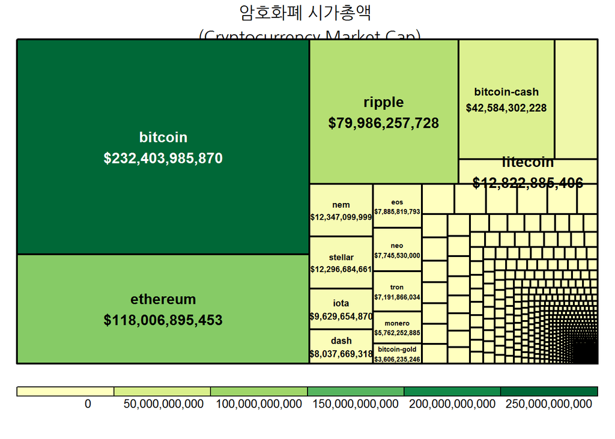

```r
## 2.2. 시각화

market_today_df <- market_today %>%
    select(id, market_cap_usd, price_usd) %>%
    filter(!is.na(id) & !is.na(market_cap_usd)) %>%
    mutate(market_cap_usd = as.numeric(market_cap_usd),
           price_usd = as.numeric(price_usd),
           formatted_market_cap = str_c(id, '\n', '$', format(market_cap_usd, big.mark = ',', scientific = FALSE, trim = TRUE)))


market_today_treemap <- treemap(market_today_df,
        index = "formatted_market_cap",
        vSize = "market_cap_usd",
        vColor = "market_cap_usd",
        title = "암호화폐 시가총액 \n (Cryptocurrency Market Cap)",
        fontsize.labels=c(12, 8),
        draw = TRUE,
        type = "value",
        fontfamily.title = "NanumGothic",
        format.legend = list(scientific = FALSE, big.mark = ","),
        title.legend="")
```

```r
# d3tree2(market_today_treemap, rootname = "암호화폐")
```

## 3. 비트코인 시세 변화 [^4]

[CoinDesk Bitcoin Price Index API](https://www.coindesk.com/api/)를 통해서 제공되는 실시간 비트코인 가격 데이터를 바탕으로 2011-01-01 부터 2018-01-12까지 비트코인 가격을 변화를 살펴보자. 이를 위해서 [coindeskr](https://cran.r-project.org/web/packages/coindeskr/index.html) 팩키지에서 데이터를 긁어오고 이를 `dygraph` 팩키지로 시각화한다.

```r
# 1. 데이터 가져오기 --------

bitcoin_krw_df <- get_historic_price(currency = "KRW", start="2011-01-01", end=Sys.Date())

bitcoin_krw_df$Price <- round(bitcoin_krw_df$Price,0)

# 2. 비트코인 가격변화 시각화 --------

dygraph(data = bitcoin_krw_df, main = paste0("비트코인 가격 동향: 2011-01-01 ... ", Sys.Date())) %>%
    dyHighlight(highlightCircleSize = 5,
                highlightSeriesBackgroundAlpha = 0.2,
                hideOnMouseOut = FALSE, highlightSeriesOpts = list(strokeWidth = 3)) %>%
    dyRangeSelector(height = 50, dateWindow = c(paste(Sys.Date()-90), paste(Sys.Date()))) %>%
    dyLegend(width = 500, show = "onmouseover", hideOnMouseOut = FALSE) %>%
    dyAxis("y",
           label = "비트코인가격(원)",
           axisLabelFormatter = 'function(d){return d.toString().replace(/\\B(?=(\\d{3})+(?!\\d))/g, ",");}',
           axisLabelFontSize = 10,
           axisLabelWidth = 70,
           valueFormatter = 'function(d){return d.toString().replace(/\\B(?=(\\d{3})+(?!\\d))/g, ",");}'
    ) %>%
    dyCSS("blockchain.css")
```

[interactive chart not shown]

[^1]: [Matthew Leonawicz, Introduction to rockchain, 2017-12-04](https://leonawicz.github.io/rockchain/articles/rockchain.html)
[^2]: [위키 백과 - 블록체인(Blockchain)](https://ko.wikipedia.org/wiki/%EB%B8%94%EB%A1%9D%EC%B2%B4%EC%9D%B8)
[^3]: [DataScience+, Analysing Cryptocurrency Market in R, October 26, 2017](https://datascienceplus.com/analysing-cryptocurrency-market-in-r/)
[^4]: [DataScience+, Building a Daily Bitcoin Price Tracker with Coindeskr and Shiny in R, January 10, 2018](https://datascienceplus.com/building-a-daily-bitcoin-price-tracker-with-coindeskr-and-shiny-in-r/)